# ETAN Database Exploration Tool

# Introduction/Summary

This tool was made to help users explor the ETAN database. Plots and tables have been provided to report descriptive statistics about tables and views in the database. The tables included in this tool can be copied and saved locally.

The data reported used for this tool was queried on 2021-06-10.

# Database Schemas

The below, left plot details the number of tables per each schema. The below, right plot details the total number of records in each schema - the coloring depicts the number of records for unique tables given a schema. Most records are in a handful of schemas and only from a few tables therein.

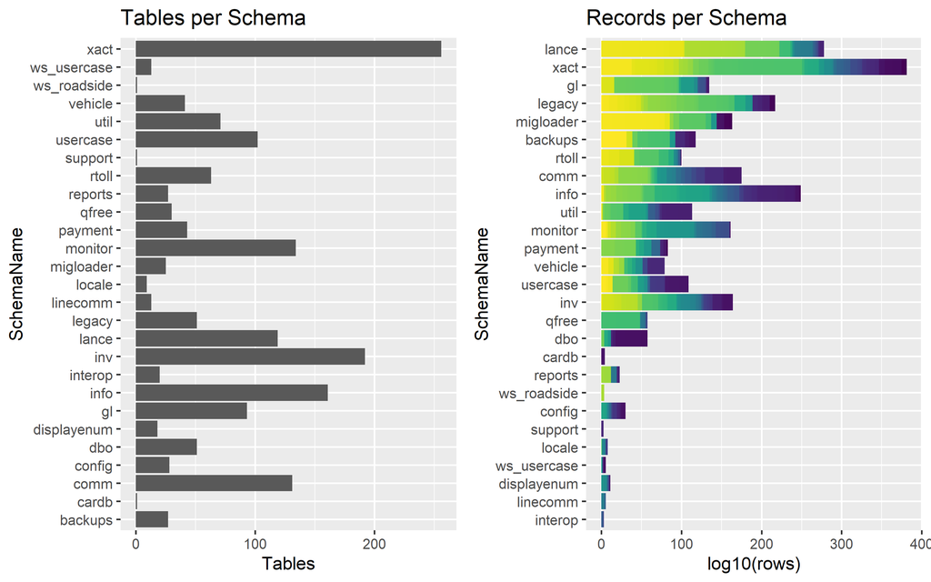

# Database Tables

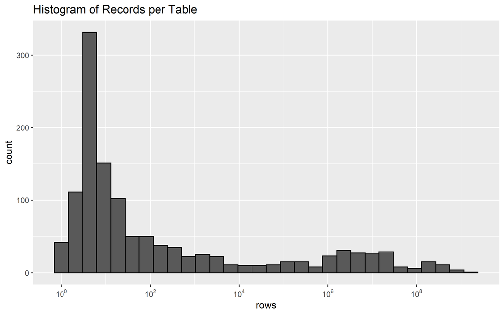

## ETAN Database Table Constraints

### Constraint Table

This table details all ETAN table constraintes - queried from ETAN database on 2021-06-14.

| From Complete | From Column | From Schema | From Rows | To Complete | To Schema | To Rows |
| --- | --- | --- | --- | --- | --- | --- |
| lance_TripPassageLp | licensePlateId | lance | 979274674 | util_LicensePlate | util | 50864788 |
| lance_TripPassageLp | tripPassageId | lance | 979274674 | lance_tripPassage | lance | 257420305 |
| lance_PassageImageURI | passageImageURIPrefixId | lance | 975402184 | lance_EnuPassageImageURIPrefix | lance | 3 |
| lance_PassageImageURI | tollImageTypeId | lance | 975402184 | xact_EnuTollImageType | xact | 6 |
| lance_PassageImageURI | tripPassageId | lance | 975402184 | lance_tripPassage | lance | 257420305 |
| lance_PassageImageURISeqOrder | tripPassageId | lance | 975034796 | lance_tripPassage | lance | 257420305 |
| xact_ledger | annotationid | xact | 321382689 | xact_Annotation | xact | 263311685 |
| xact_ledger | customerAccountId | xact | 321382689 | util_CustomerAccount | util | 4827151 |
| xact_ledger | customerAccountId | xact | 321382689 | util_CustomerAccount | util | 8085839 |
| xact_ledger | inputLocationId | xact | 321382689 | info_EnuInputLocation | info | 7 |

[output cut: 2253 more lines]

### Constraints Diagram

This diagram graphically depicts ETAN table contraints - it can be though of as an ERD (entity relationship diagram).

Keep Only

comm config gl info inv lance linecomm locale monitor payment qfree reports rtoll usercase util vehicle ws_roadside ws_usercase xact

Keep Only

comm config gl info inv lance linecomm locale monitor payment qfree reports rtoll usercase util vehicle ws_roadside ws_usercase xact

[interactive chart not shown]

## ETAN Database Views

This table depicts the views contained in the ETAN database. The *To Complete* column contains full view names (schema+view) and *From Complete* column contains full table names for the table which make said view. The table is orgainzed in a long/machine readable format.

| Entity Type | From Complete | To Complete |
| --- | --- | --- |
| USER_TABLE | comm_CommunicationRulesConfiguration | comm_IV_CommunicationConfigurationMandatory |
| USER_TABLE | comm_EnuCommunicationCategory | comm_IV_CommunicationConfigurationMandatory |
| USER_TABLE | comm_EnuCommunicationChannel | comm_IV_CommunicationConfigurationMandatory |
| USER_TABLE | comm_EnuCommunicationType | comm_IV_CommunicationConfigurationMandatory |
| USER_TABLE | comm_CommunicationRulesConfiguration | comm_IV_CommunicationConfigurationPreference |
| USER_TABLE | comm_EnuCommunicationCategory | comm_IV_CommunicationConfigurationPreference |
| USER_TABLE | comm_EnuCommunicationChannel | comm_IV_CommunicationConfigurationPreference |
| USER_TABLE | comm_EnuCommunicationType | comm_IV_CommunicationConfigurationPreference |
| USER_TABLE | info_CommunicationPreference | comm_IV_CommunicationConfigurationPreference |
| USER_TABLE | comm_Communication | comm_IV_CustomerCommunications |

[output cut: 3705 more lines]